# Touched objects exploration

Luise Rauer

30 6 2022

### Study design recommendations

- **Randomise samples** of different time points to avoid batch effects
- Include some comparable samples in each batch, in the best case **positive controls**
- Additional advice for handling **low-biomass samples** by microbiology group (e.g. add qPCR data)

### Summary of DADA2 recommendations

- **DADA2 truncLen**: cutting has to leave enough overlap for merging forward and reverse reads (>20 bp). V3-V4 16S region has an expected length of 426 bp, so cutting at 200 & 200 leaves no overlap for merging
- Also: unusual to cut forward and reverse reads symmetrically, usually forward reads are kept longer than reverse reads
- **DADA2 maxEE** could be increased from default = 2 in QIIME2 to recover more reads
- Cutting primers with **cutadapt** before using DADA2 might potentially lead to problems, because cutadapt does usually not remove primers in every sequence (as low as 70% in some samples here). This leads to different lengths per sequence and “mis-aligns” the bases per cycle, but this alignment in a prerequisite for the DADA2 error model.
- Sequences in FASTQ file have two additional bases before the primer sequence (as stated in QIIME2 script)?

## Sample processing

Based on https://benjjneb.github.io/dada2/tutorial.html.

### Set DADA2 parameters

Calculating overlap for DADA2 truncLen parameters:

- E. coli primer positions of V3V4 16S region: 341-357 forward (17 bp), 785-803 reverse (19 bp)
- Sequencing: 2x300 bp (incl. primers), or 2x296 (sequence length in FASTQ files)
- Expected amplicon length with primers: last pos. rev. primer - first pos. forw. primer = 803-341 = 462
- Expected amplicon length without primers = 426
- Overlap without truncation: Sequencing length forw. + sequencing length rev. - exp. amplicon length with primers = 300+300-462 = 138 bp overlap
- Overlap for merging with current truncation settings: truncLen forw. + truncLen rev. - exp. amplicon length with primers = 280+250-462 = 68 bp overlap
- (200+200-462 = -62 bp overlap)

```r
# Set input directory
path <- "C:/Users/rauerlui/PhD/Sonstiges/2022.05 Museum touched objects microbiome/"
# Path of input FASTQ files
path_input <- paste0(path, "FASTQ/")
# Path for output
path_output <- paste0(path, "Output/")
# Set pattern for distinguishing forward and reverse FASTQ file names
forward_pattern <- "_R1.fastq.gz"
reverse_pattern <- "_R2.fastq.gz"

# Remove primers (forward: CCTACGGGWGGCWGCAG, reverse: CTACCRGGGTATCTAATCC)
trimLeft_par <- c(17, 19)
# Set cutting parameters & leave enough overlap for merging (> 20 bp).
truncLen_par <- c(280, 250)
# Additional parameters
truncQ_par <- c(2, 2)
maxEE_par <- c(2, 2)
maxLen_par <- c(Inf, Inf)
minLen_par <- c(20, 20)
rm.phix_par <- TRUE
```

### Setting up the workspace

```r
# Load required packages
library(dada2)
library(tidyverse); packageVersion("dada2") # 1.16.0
```

```
## [1] '1.16.0'
```

```r
library(DECIPHER); packageVersion("DECIPHER") # 2.16.1
```

```
## [1] '2.16.1'
```

```r
# Set working directory
setwd(path_output)
```

### Loading files

```r
# Forward and reverse fastq filenames
fnFs <- sort(list.files(path_input, pattern = forward_pattern,
                        full.names = TRUE, recursive = TRUE))
fnRs <- sort(list.files(path_input, pattern = reverse_pattern,
                        full.names = TRUE, recursive = TRUE))
# Extract sample names
sample.names <- gsub(forward_pattern, "", basename(fnFs))
```

### Inspecting read quality

Interpretation:

- Grey-scale background: heatmap of each quality score at each base position
- Green line: mean quality score at each position
- Orange line: quartiles of the quality score distribution
- Red line: proportion of reads that extend to at least that position (not appearing if all sequences are equally long)
- Blue line: current settings for cutting sequences

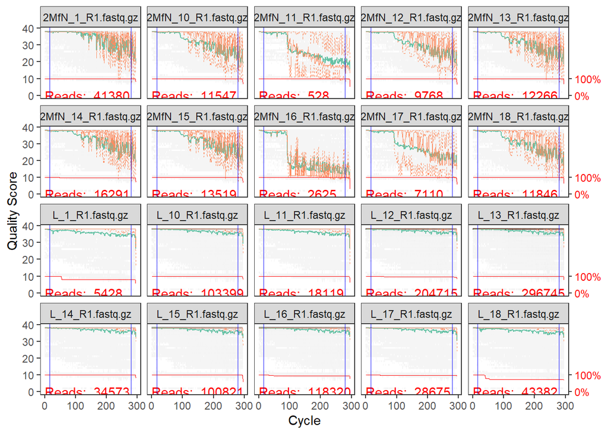

```r
# Quality profiles for forward reads
plotQualityProfile(fnFs[c(1:10, 66:75)]) +
  geom_vline(aes(xintercept = trimLeft_par[1]), colour = "blue", alpha = 0.5) +
  geom_vline(aes(xintercept = truncLen_par[1]), colour = "blue", alpha = 0.5)
```

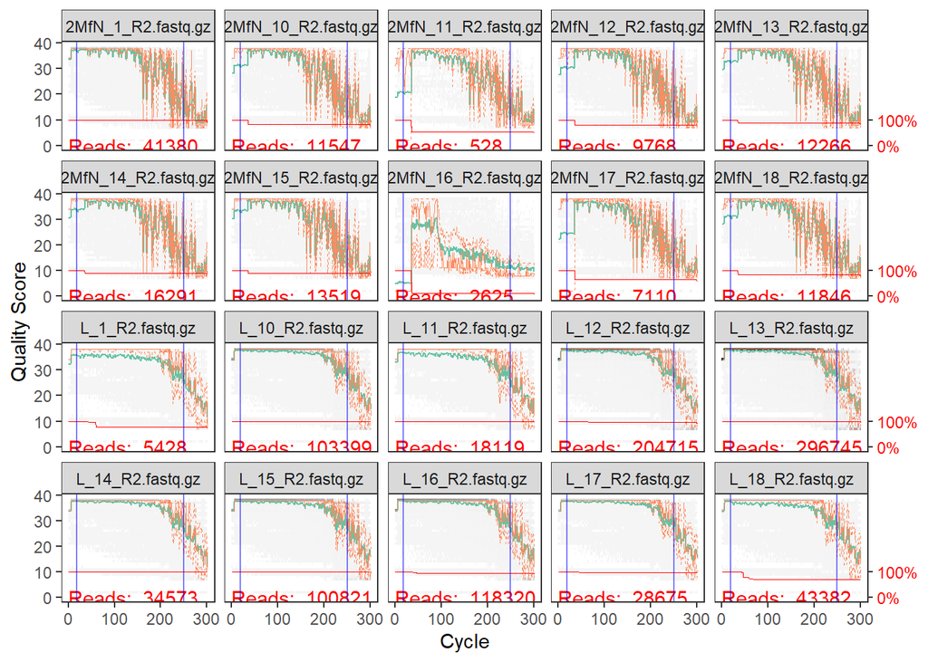

```r
# Quality profiles for reverse reads
plotQualityProfile(fnRs[c(1:10, 66:75)]) +
  geom_vline(aes(xintercept = trimLeft_par[2]), colour = "blue", alpha = 0.5) +
  geom_vline(aes(xintercept = truncLen_par[2]), colour = "blue", alpha = 0.5)
```

Second batch (upper 2 panels per figure) has a really unusual low quality, particularly in forward reads, and there is an unusual (suspicious?) termination of sequences after approx. 40 cycles (drop in red line).

### Quality filtering

```r
# Create names for filtered files and for a subdirectory of your output folder
filtFs <- file.path(path_output, "filtered",
                    paste0(sample.names, "_F_filt.fastq.gz"))
filtRs <- file.path(path_output, "filtered",
                    paste0(sample.names, "_R_filt.fastq.gz"))
names(filtFs) <- sample.names
names(filtRs) <- sample.names

# Quality filtering
out <- filterAndTrim(fwd = fnFs, filt = filtFs, rev = fnRs, filt.rev = filtRs,
                     truncLen = truncLen_par, trimLeft = trimLeft_par,
                     truncQ = truncQ_par, maxEE = maxEE_par,
                     maxLen = maxLen_par, minLen = minLen_par,
                     rm.phix = rm.phix_par, multithread = FALSE,
                     verbose = FALSE)
```

### Actual denoising

```r
# Learn the error rates
errF <- learnErrors(filtFs, multithread = FALSE, verbose = 1)
```

```
## 146636439 total bases in 557553 reads from 5 samples will be used for learning the error rates.
## Initializing error rates to maximum possible estimate.
## selfConsist step 1 .....
##    selfConsist step 2
##    selfConsist step 3
##    selfConsist step 4
##    selfConsist step 5
## Convergence after  5  rounds.
```

```r
errR <- learnErrors(filtRs, multithread = FALSE, verbose = 1)
```

```
## 128794743 total bases in 557553 reads from 5 samples will be used for learning the error rates.
## Initializing error rates to maximum possible estimate.
## selfConsist step 1 .....
##    selfConsist step 2
##    selfConsist step 3
##    selfConsist step 4
##    selfConsist step 5
## Convergence after  5  rounds.
```

Interpretation:

- Black dots: observed error rates by quality score for each base transition
- Black line: estimated error rates of the DADA2 algorithm
- Red line: expected error rates
- The black line should represent well the black dots

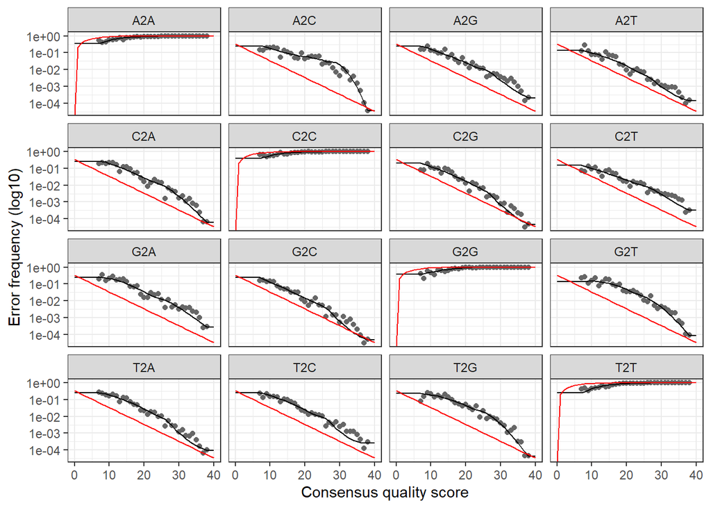

```r
# Visualize the estimated error rates
plotErrors(errF, nominalQ = TRUE)
```

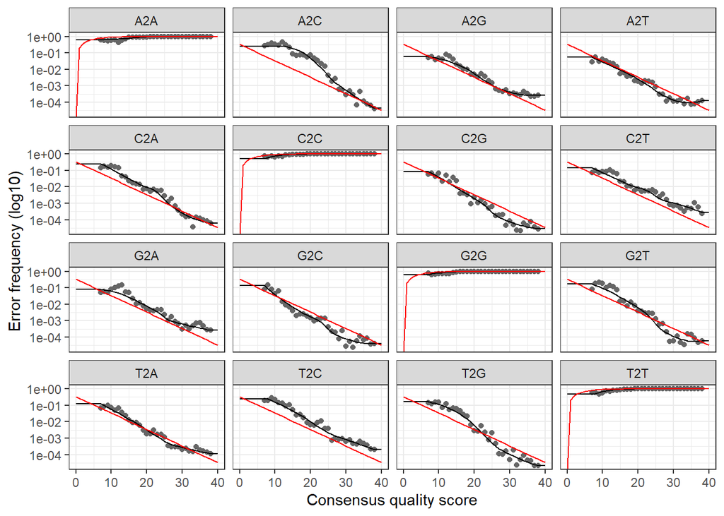

```r
plotErrors(errR, nominalQ = TRUE)
```

Estimated error rates look okay, X2X transition rates (between same bases) are usually a straighter line

### Sample inference, merging & chimera removal

```r
# Sample inference
dadaFs <- dada(filtFs[file.exists(filtFs)], err = errF, multithread = FALSE,
               verbose = FALSE)
dadaRs <- dada(filtRs[file.exists(filtRs)], err = errR, multithread = FALSE,
               verbose = FALSE)

# Merge forward and reverse reads
mergers <- mergePairs(
  dadaFs, filtFs[file.exists(filtFs)], dadaRs, filtRs[file.exists(filtRs)],
  verbose = FALSE)

# Construct a sequence table for all merged reads
seqtab <- makeSequenceTable(mergers)

# Chimera removal
seqtab.nochim <- removeBimeraDenovo(seqtab, method = "consensus",
                                    multithread = TRUE, verbose = TRUE)
```

```
## Identified 1664 bimeras out of 8356 input sequences.
```

### Sanity checks

```r
# Number of samples & Number of ASVs
dim(seqtab.nochim)
```

```
## [1]  126 6692
```

```r
# Track reads through the pipeline (here a little advanced version that works
#   even if no reads in a sample pass the filter criteria)
getN <- function(x) sum(getUniques(x))
track <- list(data.frame(out, row.names = sample.names),
              data.frame(sapply(dadaFs, getN)),
              data.frame(sapply(dadaRs, getN)),
              data.frame(sapply(mergers, getN)),
              data.frame(rowSums(seqtab.nochim)))
track <- lapply(track, function(x) rownames_to_column(x, "sample"))
track <- track %>% purrr::reduce(merge, by = "sample", all = TRUE)
track <- track %>% column_to_rownames(var = "sample")
colnames(track) <- c("input", "filtered", "denoisedF", "denoisedR", "merged",
                     "nonchim")
# Mean percentage of recovered reads per step
round(colMeans(track/track$input*100, na.rm = TRUE), 1)
```

```
##     input  filtered denoisedF denoisedR    merged   nonchim
##     100.0      49.6      48.4      47.7      46.2      45.6
```

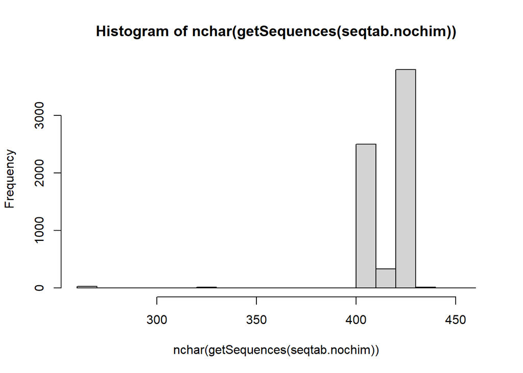

```r
# Create an ASV table for filtering steps
seqtab.filt <- seqtab.nochim
# Plot distribution of sequence lengths
hist(nchar(getSequences(seqtab.nochim)))
```

Sequence length is within the expected range of 426 bp (without primers).

```r
# Filter sequences by length (+/- 20% of expected length, i.e. 426 bp)
seqtab.filt <- seqtab.filt[, nchar(colnames(seqtab.filt)) %in% 340:512]

# Check singletons
table(apply(seqtab.filt, 2, max) > 1) # no singletons present
```

```
##
## TRUE
## 6642
```

```r
###seqtab.filt <- seqtab.filt[, apply(seqtab.filt, 2, max) > 1]

# Create an ID for each ASV
ASV_ID <- paste0("ASV_", formatC(seq(ncol(seqtab.filt)),
                                 width = nchar(ncol(seqtab.filt)), flag = "0"))
```

### Taxonomic annotation

#### Using built-in ‘assignTaxonomy’

```r
# Download the file RefSeq_16S_6-11-20_RDPv16_fullTaxo.fa.gz from
#   https://zenodo.org/record/4735821#.YO9BsUHgo2w and save the database in
#   your output directory.
Sys.time() # takes ~ 3h13min
set.seed(1)
taxa_RDP <- assignTaxonomy(
  seqtab.filt,
  paste0(path_output, "/RefSeq_16S_6-11-20_RDPv16_fullTaxo.fa.gz"),
  multithread = FALSE)
Sys.time()
```

#### Using new ‘idtaxa’

```r
# Download trained clasifiers from: http://www2.decipher.codes/Downloads.html
# Create a DNAStringSet from the ASVs
dna <- DNAStringSet(getSequences(seqtab.filt))
# Silva
load(paste0(path_output, "SILVA_SSU_r138_2019.RData"), verbose = TRUE)
Sys.time() # takes ~ 35min
ids_silva <- IdTaxa(dna, trainingSet, strand = "top", processors = NULL,
                    verbose = FALSE)
Sys.time()
ranks <- c("domain", "phylum", "class", "order", "family", "genus", "species")
# Convert the output object of class "Taxa" to a matrix (like assignTaxonomy)
taxid_silva <- t(sapply(ids_silva, function(x) {
  m <- match(ranks, x$rank)
  taxa <- x$taxon[m]
  taxa[startsWith(taxa, "unclassified_")] <- NA
  taxa
}))
colnames(taxid_silva) <- ranks; rownames(taxid_silva) <- getSequences(seqtab.filt)

# RDP
load(paste0(path_output, "RDP_v18-mod_July2020.RData"), verbose = TRUE)
Sys.time() # takes ~ 35min
ids_rdp <- IdTaxa(dna, trainingSet, strand = "top", processors = NULL,
                    verbose = FALSE)
Sys.time()
# Convert the output object of class "Taxa" to a matrix (like assignTaxonomy)
taxid_rdp <- t(sapply(ids_rdp, function(x) {
  m <- match(ranks, x$rank)
  taxa <- x$taxon[m]
  taxa[startsWith(taxa, "unclassified_")] <- NA
  taxa
}))
colnames(taxid_rdp) <- ranks; rownames(taxid_rdp) <- getSequences(seqtab.filt)
```

### Saving output

```r
# Save R objects
save(list = ls()[ls() %in% c("seqtab.nochim", "seqtab.filt", "track", "ASV_ID",
                             "taxa_RDP", "taxid_rdp", "taxid_silva",
                             "sample.names")],
     file = paste0(path_output, "/DADA2_main_objects.RData"))
```